# Unit 9 Live Session HW

Audrene Tiakor

March 11, 2019

```r
library(ggplot2) # Data visualization
library(readr) # CSV file I/O, e.g. the read_csv function
library(dplyr) # Heavy use of this library
library(tidyr)
library(plyr)
library(ggthemes) # for themes in ggplot
library(knitr)
library(kableExtra) # library to make the document more presentable
library(datasets) # to make region col
library(zoo)
library(agricolae)
library(caret) #to split data in train/test
library(FNN) #for knn regression
library(class)
```

#### Background: Brewmeisters in Colorado and Texas have teamed up to analyze the relationship between ABV and IBU in each of their states. Use the data sets from the project to help them in their analysis. There three main questions of interest are 1) is there significant linear relationship between AVB (response,y) and IBU (explanatory, x), 2) Is this relationship different between beers in Colorado and Texas and 3) Is there a significant quadratic component in this relationship for either Colorado or Texas or both?

### A. Clean and Prepare The Data:

1. Create column for brewery ID that is common to both datasets similar to what you did in the project, so we can merge!

```r
# Read in beer and breweries data set using _csv for more tidy output
Beers <- read_csv('Beers.csv', col_types = cols())
Breweries <- read_csv('Breweries.csv', col_types = cols())
```

2. Merge the beer and brewery data into a single dataframe.

```r
BrewPub <- merge(Beers, Breweries, by.x = "Brewery_id", by.y = "Brew_ID", all = TRUE)
# Change variable names to more meaningful title

BrewPub <- rename(BrewPub, c("Name.x"="Beer","Name.y"="Brewery",
                   "Ounces"="OZ"))
```

3. Clean the State Column…get rid of extraneous white space.

```r
trimws(BrewPub$State)
```

[output not shown]

[output cut: 171 more lines]

4. Create one dataset that has only Colorado and Texas beers and no IBU NAs…name it “beerCOTX”.

```r
#extract information for Texas from BrewPub (merged dataset)
Texas <- BrewPub[which(BrewPub$State == 'TX'),names(BrewPub) %in% c("Brewery_id","Beer","Beer_ID","ABV","IBU","Style","OZ","Brewery","City","State")] %>% na.omit()


#extract information for Texas from BrewPub (merged dataset)
Colorado <- BrewPub[which(BrewPub$State == 'CO'),names(BrewPub) %in% c("Brewery_id","Beer","Beer_ID","ABV","IBU","Style","OZ","Brewery","City","State")] %>% na.omit()


#Creating beerCOTX
beerCOTX<-rbind(Texas, Colorado)

#Check for any NA's
any(is.na(beerCOTX))
```

```
## [1] FALSE
```

5. Order beerCOTX by IBU (ascending) … this will be important later in graphing.

```r
#sorting IBU in ascending order
beerCOTX[]<-lapply(beerCOTX, as.character)
beerCOTX[order(beerCOTX$IBU),]
```

```
##      Brewery_id                                                Beer
## 460          67                                             Rye Wit
## 280          38                                        White Rascal
## 699         119                                 Valkyrie Double IPA
## 703         119                                PRO-AM (2012) (2012)
## 747         128                            Dream Crusher Double IPA
## 673         111                                    Redacted Rye IPA
## 674         111                     Elevation Triple India Pale Ale
## 676         111                             Ryeteous Rye IPA (2012)
## 1018        167                                  GUBNA Imperial IPA
## 2255        497                                     Hop Abomination
## 1267        221                                  Hemlock Double IPA
## 698         119                                    Red Cockaded Ale
## 700         119                             Red Cockaded Ale (2013)
## 1249        215                                        More Cowbell
```

[output cut: 690 more lines]

### B. Create An Initial Plot Of The Data

6. Plot ABV v. IBU for both Colorado and Texas (two separate plots)…use ggplot and facets.

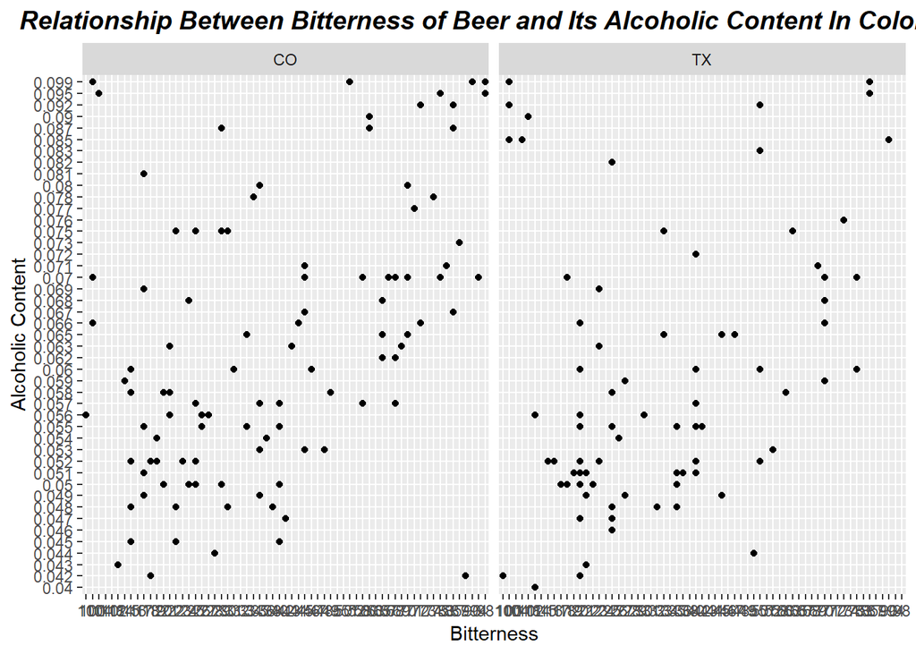

```r
#For ABV and IBU relationship model in Texas and Colorado

ggplot(beerCOTX, aes(x=beerCOTX$IBU, y=beerCOTX$ABV)) + geom_point() + geom_smooth(method=lm, se=FALSE) + theme(plot.title = element_text(size=14,hjust= 0.5, face="bold.italic")) + ggtitle("Relationship Between Bitterness of Beer and Its Alcoholic Content In Colorado") +
  labs(x="Bitterness",y="Alcoholic Content") + facet_grid(.~State)
```

###C. Model the Data 7. For each state, fit a simple linear regression model to assess the relationship between ABV and IBU. Use the regular plot funtion in base R(not ggplot) to create a scatter plot with the regresson line superimposed on the plot. Again, this should be done for each state.

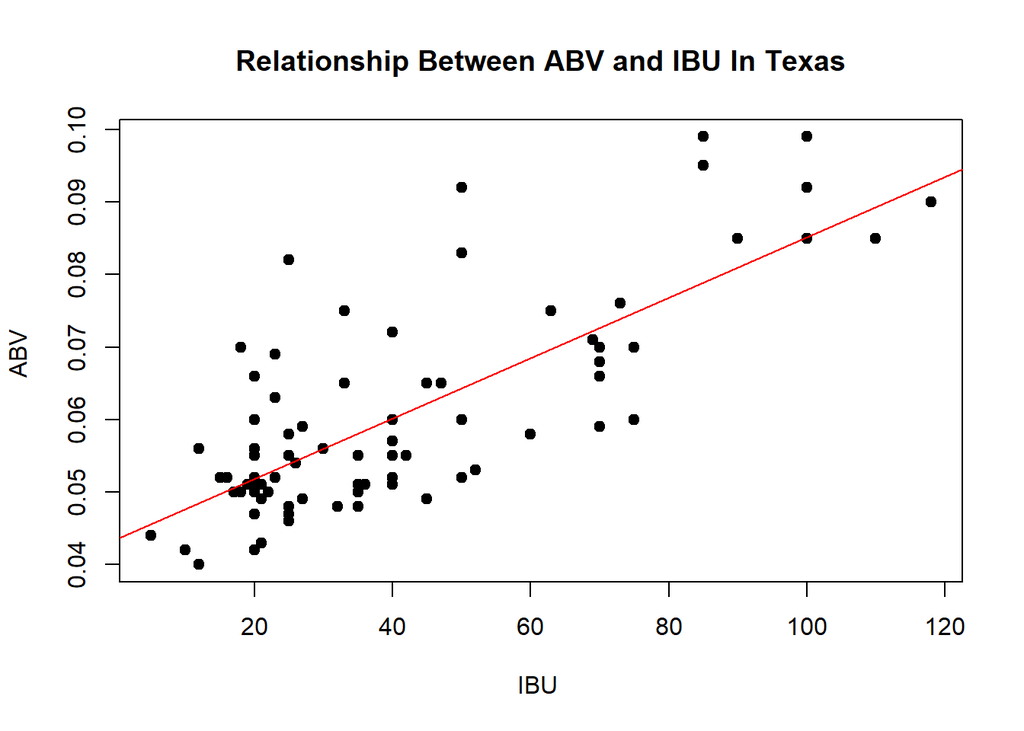

```r
#For Texas
attach(Texas)
plot(IBU, ABV, main="Relationship Between ABV and IBU In Texas",
     xlab="IBU ", ylab="ABV ", pch=19)
abline(lm(ABV~IBU), col="red")
```

```r
#For Colorado
attach(Colorado)
```

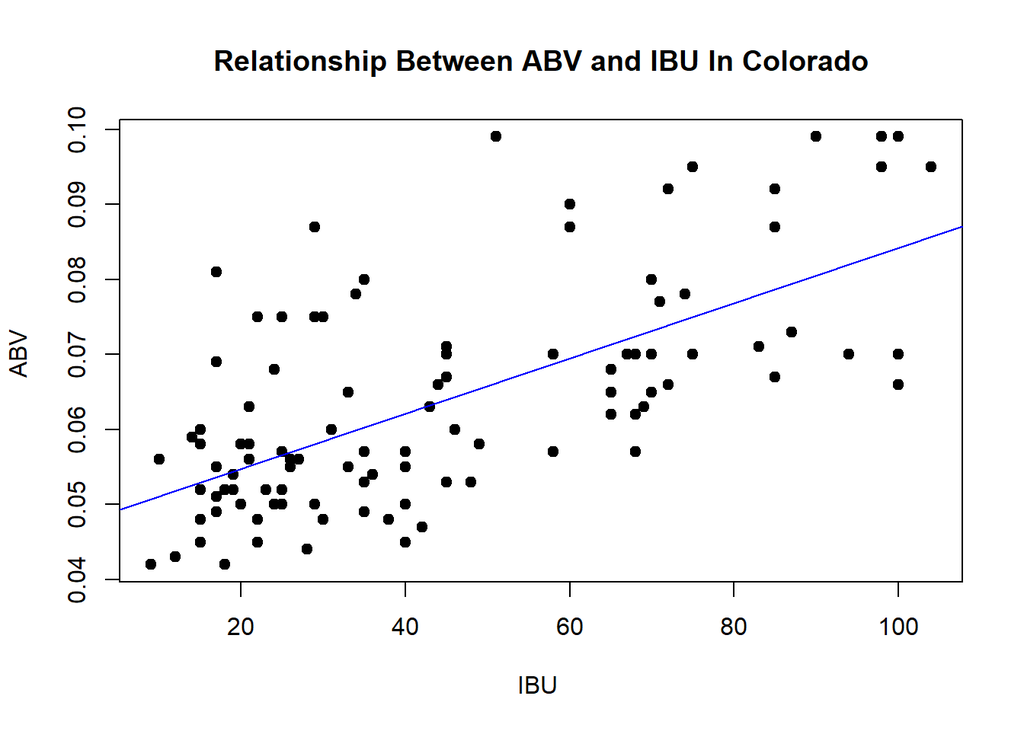

```r
plot(IBU, ABV, main="Relationship Between ABV and IBU In Colorado",
     xlab="IBU ", ylab="ABV ", pch=19)
abline(lm(ABV~IBU), col="blue")
```

8. Address the assumptions of the regression model. You may assume the data are independent(even if this is a stretch): 1. There is a normal distribution of the ABV for fixed values of IBU. 2. These normal distributions have equal standard deviations. 3. The means of these normal distributions have a linear relationship with IBU. 4. Independence(you may assum this one ot be true without defense.)

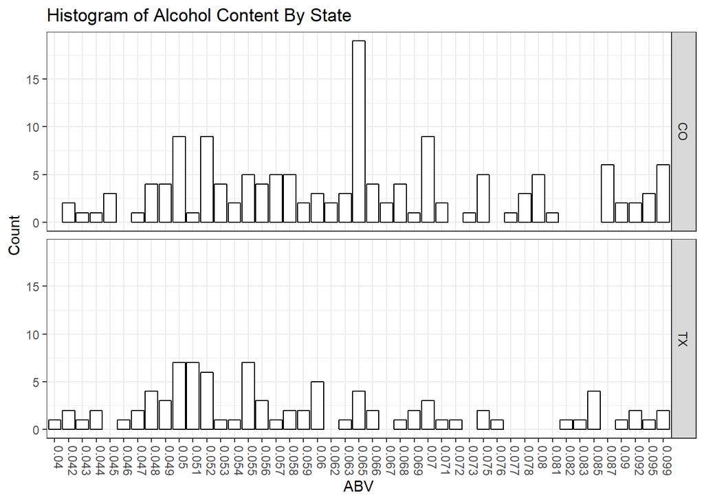

```r
ABV_Hist <- ggplot(beerCOTX,aes(x=ABV)) + geom_histogram(colour="black", fill="white", stat="count") + theme(axis.text.x=element_text(size=7), plot.title = element_text(size=14,hjust = 0.5, face="bold.italic")) + theme_bw() + ggtitle("Histogram of Alcohol Content By State") + labs(x="ABV",y="Count") + theme(axis.text.x = element_text(angle = -90, hjust = 0, vjust = 0)) + facet_grid(State~.)
ABV_Hist
```

```r
#For Texas
Texaslm<-lm(ABV~IBU, data = Texas)
summary(Texaslm)
```

```
##
## Call:
## lm(formula = ABV ~ IBU, data = Texas)
##
## Residuals:
##       Min        1Q    Median        3Q       Max
## -0.014770 -0.005805 -0.001593  0.003360  0.028071
##
## Coefficients:
##              Estimate Std. Error t value Pr(>|t|)
## (Intercept) 4.351e-02  1.791e-03   24.29   <2e-16 ***
## IBU         4.168e-04  3.709e-05   11.24   <2e-16 ***
## ---
## Signif. codes:  0 '***' 0.001 '**' 0.01 '*' 0.05 '.' 0.1 ' ' 1
##
## Residual standard error: 0.009128 on 86 degrees of freedom
## Multiple R-squared:  0.5949, Adjusted R-squared:  0.5902
## F-statistic: 126.3 on 1 and 86 DF,  p-value: < 2.2e-16
```

```r
#For Colorado
Coloradolm<-lm(ABV~IBU, data = Colorado)
summary(Coloradolm)
```

```
##
## Call:
## lm(formula = ABV ~ IBU, data = Colorado)
##
## Residuals:
##       Min        1Q    Median        3Q       Max
## -0.018158 -0.007266 -0.003293  0.006453  0.032853
##
## Coefficients:
##              Estimate Std. Error t value Pr(>|t|)
## (Intercept) 4.740e-02  1.856e-03   25.54   <2e-16 ***
## IBU         3.676e-04  3.432e-05   10.71   <2e-16 ***
## ---
## Signif. codes:  0 '***' 0.001 '**' 0.01 '*' 0.05 '.' 0.1 ' ' 1
##
## Residual standard error: 0.01077 on 144 degrees of freedom
## Multiple R-squared:  0.4433, Adjusted R-squared:  0.4395
## F-statistic: 114.7 on 1 and 144 DF,  p-value: < 2.2e-16
```

*Interpretation of slope for Colorado model*: It is estimated that for every increase in IBV per unit, the estimated ABV increases by 0.0003676.

10. Provide a confidence interval for each slope (from each state). Provide a sentence that interprets each slope(for each state) but this time include the confidence interval in your interpretation. Answer this question: Is there significant evidence that the relationship between ABV and IBU is significanlty different for Texas and Colorado beers?

*Confidence Interval for Slope (Texas): The confidence interval for slope in regards to Texas is (0.000344, 0.000490). We are 95% confident that when the IBU increases per unit, the mean amount of ABV increases between (0.000344, 0.000490).

### E. Compare Two competing Models: External Cross Validation

11. Using the beerCOTX dataframe, add a column to the data that is the square of the IBU column. Call it IBU2. Print the head of the dataframe with the new column.

```r
beerCOTX$IBU2<-(as.numeric(beerCOTX$IBU))^2
head(beerCOTX, 10)
```

```
##     Brewery_id                           Beer Beer_ID   ABV IBU
## 226         30                     Gone A-Rye    2600 0.085  90
## 228         30                    Dankosaurus    2052 0.068  70
## 229         30           Scruffy's Smoked Alt    1584 0.051  35
## 230         30 Elliott's Phoned Home Pale Ale    1182 0.051  36
## 231         30                The Lawn Ranger    1050  0.05  18
## 283         39                      Cow Creek    2588 0.054  26
## 284         39                     Chupahopra    2458 0.075  63
## 285         39                      Twisted X    2212 0.051  19
## 456         67                       Texicali    2526 0.065  33
## 458         67               Bat Outta Helles    2524 0.042  20
##                              Style OZ                   Brewery
## 226 American Double / Imperial IPA 16       Cedar Creek Brewery
## 228                   American IPA 16       Cedar Creek Brewery
## 229                    Smoked Beer 16       Cedar Creek Brewery
```

[output cut: 18 more lines]

12.For each state, create a training and test set from the data (60%/40% split respectively). Print a summary of each new data frame…there should be four: TrainingCo, TestCo, TrainingTX, TestTX.

```r
#create training and test set for Colorado, 60% train, 40% test
set.seed(123)
samp_size<-floor(0.60*nrow(Colorado))
train_ind<-sample(seq_len(nrow(Colorado)),size=samp_size)
TrainingCO<-Colorado[train_ind,]
TestCO<-Colorado[-train_ind,]

#create training and test set for Texas, 60% train, 40% test

samp_size<-floor(0.60*nrow(Texas))
train_ind<-sample(seq_len(nrow(Texas)),size=samp_size)
TrainingTX<-Texas[train_ind,]
TestTX<-Texas[-train_ind,]

#Print Summary of each: TrainingCO, TestCO, TrainingTX, TestTX
summary(TrainingCO)
```

```
##    Brewery_id        Beer              Beer_ID            ABV
##  Min.   :  7.0   Length:87          Min.   :   1.0   Min.   :0.04200
##  1st Qu.:108.0   Class :character   1st Qu.: 590.5   1st Qu.:0.05250
##  Median :167.0   Mode  :character   Median : 808.0   Median :0.06300
##  Mean   :244.3                      Mean   :1046.3   Mean   :0.06397
##  3rd Qu.:418.0                      3rd Qu.:1457.5   3rd Qu.:0.07000
##  Max.   :524.0                      Max.   :2644.0   Max.   :0.09900
##       IBU            Style                 OZ          Brewery
##  Min.   : 10.00   Length:87          Min.   :12.00   Length:87
##  1st Qu.: 24.00   Class :character   1st Qu.:12.00   Class :character
##  Median : 35.00   Mode  :character   Median :12.00   Mode  :character
##  Mean   : 44.51                      Mean   :13.29
##  3rd Qu.: 65.00                      3rd Qu.:16.00
##  Max.   :100.00                      Max.   :19.20
##      City              State
##  Length:87          Length:87
##  Class :character   Class :character
##  Mode  :character   Mode  :character
##
##
##
```

```r
summary(TestCO)
```

```
##    Brewery_id      Beer              Beer_ID            ABV
##  Min.   : 38   Length:59          Min.   :   4.0   Min.   :0.04200
##  1st Qu.:111   Class :character   1st Qu.: 602.5   1st Qu.:0.05650
##  Median :167   Mode  :character   Median :1176.0   Median :0.06500
##  Mean   :252                      Mean   :1128.0   Mean   :0.06612
##  3rd Qu.:413                      3rd Qu.:1583.5   3rd Qu.:0.07300
##  Max.   :521                      Max.   :2434.0   Max.   :0.09900
##       IBU            Style                 OZ          Brewery
##  Min.   :  9.00   Length:59          Min.   :12.00   Length:59
##  1st Qu.: 28.50   Class :character   1st Qu.:12.00   Class :character
##  Median : 58.00   Mode  :character   Median :12.00   Mode  :character
##  Mean   : 51.75                      Mean   :12.94
##  3rd Qu.: 70.00                      3rd Qu.:12.00
##  Max.   :104.00                      Max.   :19.20
##      City              State
##  Length:59          Length:59
##  Class :character   Class :character
##  Mode  :character   Mode  :character
##
##
##
```

```r
summary(TrainingTX)
```

```
##    Brewery_id        Beer              Beer_ID          ABV
##  Min.   : 30.0   Length:52          Min.   :  44   Min.   :0.04000
##  1st Qu.:119.0   Class :character   1st Qu.:1040   1st Qu.:0.05000
##  Median :127.0   Mode  :character   Median :1818   Median :0.05750
##  Mean   :161.5                      Mean   :1599   Mean   :0.06173
##  3rd Qu.:193.0                      3rd Qu.:2200   3rd Qu.:0.07000
##  Max.   :427.0                      Max.   :2526   Max.   :0.09900
##       IBU            Style                 OZ          Brewery
##  Min.   : 12.00   Length:52          Min.   :12.00   Length:52
##  1st Qu.: 20.00   Class :character   1st Qu.:12.00   Class :character
##  Median : 38.00   Mode  :character   Median :12.00   Mode  :character
##  Mean   : 44.94                      Mean   :12.77
##  3rd Qu.: 64.50                      3rd Qu.:12.00
##  Max.   :118.00                      Max.   :16.00
##      City              State
##  Length:52          Length:52
##  Class :character   Class :character
##  Mode  :character   Mode  :character
##
##
##
```

```r
summary(TestTX)
```

```
##    Brewery_id        Beer              Beer_ID          ABV
##  Min.   : 30.0   Length:36          Min.   :  45   Min.   :0.0420
##  1st Qu.:119.0   Class :character   1st Qu.:1839   1st Qu.:0.0510
##  Median :141.0   Mode  :character   Median :2060   Median :0.0550
##  Mean   :159.7                      Mean   :1906   Mean   :0.0585
##  3rd Qu.:216.0                      3rd Qu.:2248   3rd Qu.:0.0635
##  Max.   :288.0                      Max.   :2600   Max.   :0.0990
##       IBU            Style                 OZ          Brewery
##  Min.   :  5.00   Length:36          Min.   :12.00   Length:36
##  1st Qu.: 21.00   Class :character   1st Qu.:12.00   Class :character
##  Median : 27.00   Mode  :character   Median :12.00   Mode  :character
##  Mean   : 34.19                      Mean   :12.89
##  3rd Qu.: 42.75                      3rd Qu.:12.00
##  Max.   :100.00                      Max.   :16.00
##      City              State
##  Length:36          Length:36
##  Class :character   Class :character
##  Mode  :character   Mode  :character
##
##
##
```

```r
#Cross Validation of Training/Test Data for Colorado and Texas

#Model 1 (Texas)

fitTrainingTX = lm(ABV~IBU, data = TrainingTX)
#How well did the method recover the true parameter values (intercept and slope).
summary(fitTrainingTX)
```

```
##
## Call:
## lm(formula = ABV ~ IBU, data = TrainingTX)
##
## Residuals:
##       Min        1Q    Median        3Q       Max
## -0.014460 -0.007029 -0.001755  0.003171  0.028127
##
## Coefficients:
##              Estimate Std. Error t value Pr(>|t|)
## (Intercept) 0.0426976  0.0025033  17.057  < 2e-16 ***
## IBU         0.0004235  0.0000471   8.991 5.08e-12 ***
## ---
## Signif. codes:  0 '***' 0.001 '**' 0.01 '*' 0.05 '.' 0.1 ' ' 1
##
## Residual standard error: 0.009634 on 50 degrees of freedom
## Multiple R-squared:  0.6178, Adjusted R-squared:  0.6102
## F-statistic: 80.84 on 1 and 50 DF,  p-value: 5.078e-12
```

```r
# These are the predictions of the model on the data that were used to fit the model.
predsTrainingTX = predict(fitTrainingTX)
TrainingTX$preds = predsTrainingTX
TrainingTX
```

```
##      Brewery_id                               Beer Beer_ID   ABV IBU
## 1402        258                         LuckenBock    1972 0.070  18
## 1361        243                             Hijack    1774 0.055  20
## 698         119                   Red Cockaded Ale    1728 0.085 110
## 461          67                         Soul Doubt    2521 0.059  70
## 954         162                     Rubberneck Red    2197 0.050  35
## 736         126                   Karbachtoberfest    1458 0.055  25
## 953         162                      Pretzel Stout    2268 0.065  47
## 733         126                Weisse Versa (2012)    2374 0.052  16
## 1965        396                           Pale Dog     501 0.060  50
## 1125        188        Robert Earl Keen Honey Pils    2144 0.050  17
## 285          39                          Twisted X    2212 0.051  19
## 743         127                     The Green Room    2372 0.060  75
## 747         128           Dream Crusher Double IPA    2166 0.085 100
## 756         129                             BLAKKR    1861 0.099  85
```

[output cut: 144 more lines]

```r
# These are the predictions of the model on the data that were NOT used to fit the model.
# This is a better measure of how the model will perform in real life
predsTestTX = predict(fitTrainingTX, newdata = TestTX)
TestTX$preds = predsTestTX
TestTX
```

```
##      Brewery_id                            Beer Beer_ID   ABV IBU
## 226          30                      Gone A-Rye    2600 0.085  90
## 228          30                     Dankosaurus    2052 0.068  70
## 229          30            Scruffy's Smoked Alt    1584 0.051  35
## 283          39                       Cow Creek    2588 0.054  26
## 460          67                         Rye Wit    2522 0.042  10
## 462          67              Yo Soy Un Berliner    2520 0.044   5
## 695         119              Pine Belt Pale Ale    2387 0.065  45
## 697         119                  Le Mort Vivant    1740 0.069  23
## 703         119            PRO-AM (2012) (2012)     853 0.099 100
## 707         119              Pine Belt Pale Ale      45 0.065  45
## 746         128            Oak Cliff Coffee Ale    2251 0.075  33
## 752         128                   Dallas Blonde     946 0.052  23
## 754         129           18th Anniversary Gose    2370 0.044   5
## 757         129   Firemans #4 Blonde Ale (2013)    1718 0.051  21
```

[output cut: 96 more lines]

```r
# Calculation of the MSE for the training set
ASEholderTrainingTX = sum((predsTrainingTX - TrainingTX$ABV)^2)/(length(TrainingTX$ABV))
#do this for ASE
# Calculation of the MSE for the Test set
ASEholderTestTX = sum((predsTestTX - TestTX$ABV)^2)/(length(TestTX$ABV))

ASEholderTrainingTX
```

```
## [1] 8.924883e-05
```

```r
ASEholderTestTX
```

```
## [1] 7.093377e-05
```

```r
#Model 2 (Colorado)


fitTrainingCO = lm(ABV~IBU, data = TrainingCO)
#How well did the method recover the true parameter values (intercept and slope).
summary(fitTrainingCO)
```

```
##
## Call:
## lm(formula = ABV ~ IBU, data = TrainingCO)
##
## Residuals:
##       Min        1Q    Median        3Q       Max
## -0.017284 -0.006650 -0.002702  0.005186  0.032611
##
## Coefficients:
##              Estimate Std. Error t value Pr(>|t|)
## (Intercept) 4.736e-02  2.299e-03  20.599  < 2e-16 ***
## IBU         3.731e-04  4.492e-05   8.307 1.36e-12 ***
## ---
## Signif. codes:  0 '***' 0.001 '**' 0.01 '*' 0.05 '.' 0.1 ' ' 1
##
## Residual standard error: 0.01059 on 85 degrees of freedom
## Multiple R-squared:  0.4481, Adjusted R-squared:  0.4416
## F-statistic: 69.01 on 1 and 85 DF,  p-value: 1.362e-12
```

```r
# These are the predictions of the model on the data that were used to fit the model.
predsTrainingCO = predict(fitTrainingCO)
TrainingCO$preds = predsTrainingCO
TrainingCO
```

```
##      Brewery_id                                                Beer
## 674         111                     Elevation Triple India Pale Ale
## 2047        425                                 Silverback Pale Ale
## 886         149                       Psycho Penguin Vanilla Porter
## 2256        497                                      Apricot Blonde
## 2277        504                                     Old Chub (2004)
## 378          52 Lee Hill Series Vol. 3 - Barrel Aged Imperial Stout
## 1016        167                             Ten Fidy Imperial Stout
## 2195        473                                      Summertime Ale
## 1019        167                                            Old Chub
## 999         167                            Mama's Little Yella Pils
## 2274        504                      Ten Fidy Imperial Stout (2008)
## 998         167                                     Dale's Pale Ale
## 1505        292                           Ornery Amber Lager (2003)
## 2281        504                              Dale's Pale Ale (2004)
```

[output cut: 249 more lines]

```r
# These are the predictions of the model on the data that were NOT used to fit the model.
# This is a better measure of how the model will perform in real life
predsTestCO = predict(fitTrainingCO, newdata = TestCO)
TestCO$preds = predsTestCO
TestCO
```

```
##      Brewery_id                                 Beer Beer_ID   ABV IBU
## 279          38 Avery Joes Premium American Pilsner     146 0.047  42
## 281          38                 Avery India Pale Ale     107 0.063  69
## 383          52      Upslope Imperial India Pale Ale    1315 0.099  90
## 386          52       Upslope Belgian Style Pale Ale     683 0.075  30
## 389          52                  Upslope Craft Lager     444 0.048  22
## 544          83                                Shift    1987 0.050  29
## 545          83                     1554 Black Lager    1978 0.056  21
## 550          83                   Fat Tire Amber Ale    1586 0.052  18
## 554          83                           Ranger IPA     564 0.065  70
## 556          83                 Ranger IPA (Current)     115 0.065  70
## 558          83            Fat Tire Amber Ale (2008)      71 0.052  18
## 643         105                       Peach Pale Ale    2434 0.057  40
## 649         108           Firestarter India Pale Ale    2422 0.066  72
## 658         108      Screaming Eagle Special Ale ESB    1360 0.048  38
```

[output cut: 165 more lines]

```r
# Calculation of the MSE for the training set
ASEholderTrainingCO = sum((predsTrainingCO - TrainingCO$ABV)^2)/(length(TrainingCO$ABV))
#do this for ASE
# Calculation of the MSE for the Test set
ASEholderTestCO = sum((predsTestCO - TestCO$ABV)^2)/(length(TestCO$ABV))

ASEholderTrainingCO
```

```
## [1] 0.0001095528
```

```r
ASEholderTestCO
```

```
## [1] 0.0001218146
```